# Rice Classification Analysis: Cammeo vs Osmancik

Giulia Colapinto

2026-03-12

# 1. Data Loading and Pre-processing

First, we load the dataset in ARFF format. The goal is to classify two types of rice based on their morphological features. We transform the target class into a binary variable where Cammeo is represented by 1 and Osmancik by 0.

```r
# Set your path accordingly
# setwd("/set/your/path")

# Load the data
rice <- readARFF("rice.arff")

# Binary transformation
target_label <- unlist(rice$Class)
target_binary <- ifelse(target_label == "Cammeo", 1, 0)
dataset <- data.frame(rice[, 1:7], Class = target_binary)

# Splitting into Training (80%) and Test (20%) sets
set.seed(42)
n_rows <- nrow(dataset)
train_indices <- sample(1:n_rows, size = 0.8 * n_rows)

train_set <- dataset[train_indices, ]
test_set <- dataset[-train_indices, ]
```

# 2. Exploratory Data Analysis (EDA)

Before modeling, let’s visualize the distribution of the features and the correlation between variables.

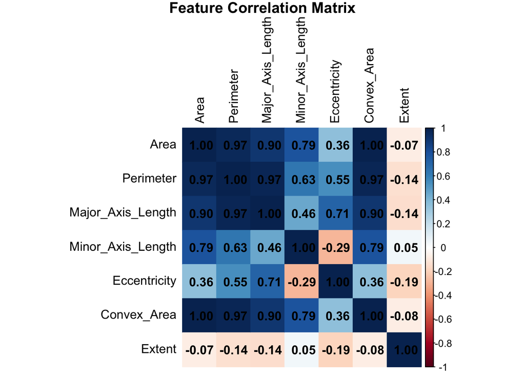

```r
# Correlation Matrix
corr_matrix <- cor(train_set[, 1:7])
corrplot(corr_matrix, method = "color", addCoef.col = "black",
         tl.col = "black", title = "Feature Correlation Matrix", mar=c(0,0,1,0))
```

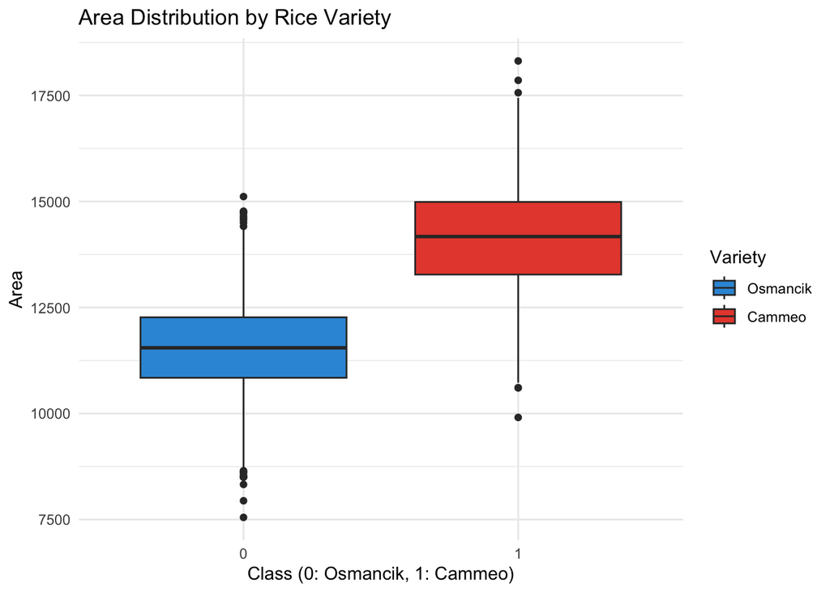

```r
# Distribution of Area by Class
ggplot(train_set, aes(x = as.factor(Class), y = Area, fill = as.factor(Class))) +
  geom_boxplot() +
  scale_fill_manual(values = c("#3498db", "#e74c3c"), labels = c("Osmancik", "Cammeo")) +
  labs(title = "Area Distribution by Rice Variety", x = "Class (0: Osmancik, 1: Cammeo)", fill = "Variety") +
  theme_minimal()
```

# 3. Model Training: Logistic Regression vs K-NN

We split the training set further to create a Validation Set (25% of the training data) to tune the K-Nearest Neighbors hyperparameter.

```r
set.seed(42)
val_indices <- sample(1:nrow(train_set), size = 0.25 * nrow(train_set))
train_sub <- train_set[-val_indices, ]
val_set <- train_set[val_indices, ]
```

# 3.1 Logistic Regression

We fit a generalized linear model (GLM) using the binomial family.

```r
mod_log <- glm(Class ~ ., data = train_sub, family = "binomial")
prob_log_val <- predict(mod_log, newdata = val_set, type = "response")
pred_log_val <- ifelse(prob_log_val > 0.5, 1, 0)

summary(mod_log)
```

```
##
## Call:
## glm(formula = Class ~ ., family = "binomial", data = train_sub)
##
## Coefficients:
##                     Estimate Std. Error z value Pr(>|z|)
## (Intercept)       -98.239405  70.645655  -1.391   0.1643
## Area               -0.006138   0.002013  -3.049   0.0023 **
## Perimeter          -0.102784   0.040589  -2.532   0.0113 *
## Major_Axis_Length   0.099056   0.142359   0.696   0.4865
## Minor_Axis_Length  -0.060532   0.354975  -0.171   0.8646
## Eccentricity       99.552610  68.911605   1.445   0.1486
## Convex_Area         0.009258   0.001865   4.964 6.92e-07 ***
## Extent              0.379599   1.246490   0.305   0.7607
## ---
## Signif. codes:  0 '***' 0.001 '**' 0.01 '*' 0.05 '.' 0.1 ' ' 1
##
## (Dispersion parameter for binomial family taken to be 1)
##
##     Null deviance: 3118.91  on 2285  degrees of freedom
## Residual deviance:  801.28  on 2278  degrees of freedom
## AIC: 817.28
##
## Number of Fisher Scoring iterations: 7
```

```r
acc_log <- mean(pred_log_val == val_set$Class)
cat("Logistic Regression Validation Accuracy:", round(acc_log, 4))
```

```
## Logistic Regression Validation Accuracy: 0.9252
```

# 3.2 K-Nearest Neighbors (K-NN)

Since K-NN is distance-based, we apply Min-Max Normalization to the features.

```r
normalize <- function(x) { (x - min(x)) / (max(x) - min(x)) }

train_sub_norm <- as.data.frame(lapply(train_sub[, 1:7], normalize))
val_set_norm <- as.data.frame(lapply(val_set[, 1:7], normalize))

best_k <- 1
best_acc_knn <- 0
k_values <- c(3, 5, 7, 9, 11)
acc_results <- numeric(length(k_values))

for(i in seq_along(k_values)) {
  k <- k_values[i]
  pred_knn <- knn(train = train_sub_norm, test = val_set_norm,
                  cl = train_sub$Class, k = k)
  acc_knn <- mean(pred_knn == val_set$Class)
  acc_results[i] <- acc_knn

  if(acc_knn > best_acc_knn) {
    best_acc_knn <- acc_knn
    best_k <- k
  }
}

cat("Best K found:", best_k, "with Accuracy:", round(best_acc_knn, 4))
```

```
## Best K found: 11 with Accuracy: 0.9213
```

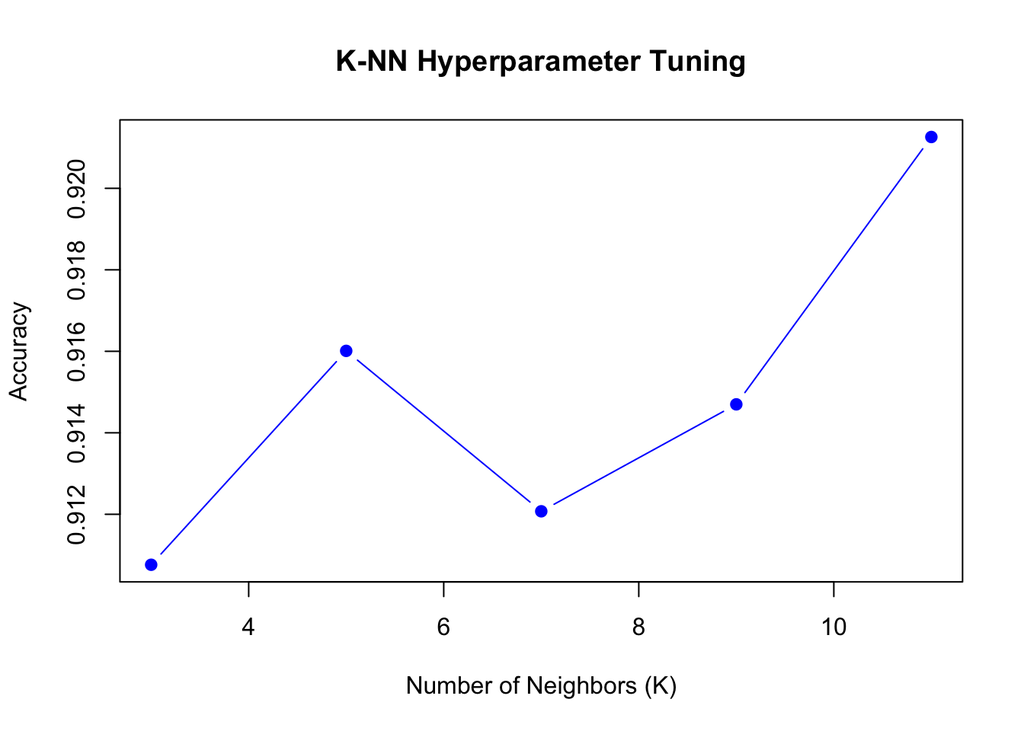

```r
# Visualize K-NN tuning
plot(k_values, acc_results, type = "b", pch = 19, col = "blue",
     xlab = "Number of Neighbors (K)", ylab = "Accuracy", main = "K-NN Hyperparameter Tuning")
```

# 4. Final Model: Logistic Regression Analysis

Since Logistic Regression outperformed K-NN, we selected it as our final model. It is particularly effective here as it handles the linear relationships between morphological features and the rice variety well.

# 4.1 Evaluation Metrics on Test Set

We retrain the model on the full training set and evaluate it on the unseen test set.

```r
# Final Model Training
modello_finale <- glm(Class ~ ., data = train_set, family = "binomial")

# Probability and Class Predictions
prob_test <- predict(modello_finale, newdata = test_set, type = "response")
pred_test <- ifelse(prob_test > 0.5, 1, 0)

# Custom Metrics Functions
calc_acc <- function(vera, pred) { mean(vera == pred) }
calc_f1 <- function(vera, pred) {
  tp <- sum(vera == 1 & pred == 1); fp <- sum(vera == 0 & pred == 1); fn <- sum(vera == 1 & pred == 0)
  p <- tp/(tp+fp); r <- tp/(tp+fn)
  return(2 * (p * r) / (p + r))
}
calc_logloss <- function(vera, prob) {
  prob <- pmax(pmin(prob, 1 - 1e-15), 1e-15)
  -mean(vera * log(prob) + (1 - vera) * log(1 - prob))
}

# Display Results
results <- data.frame(
  Accuracy = calc_acc(test_set$Class, pred_test),
  F1_Score = calc_f1(test_set$Class, pred_test),
  Log_Loss = calc_logloss(test_set$Class, prob_test)
)

print("Final Model Performance (Logistic Regression)")
```

```
## [1] "Final Model Performance (Logistic Regression)"
```

```r
print(results)
```

```
##    Accuracy  F1_Score  Log_Loss
## 1 0.9343832 0.9240122 0.1859138
```

# 4.2 Threshold and ROC Curve

The Logistic Regression model outputs probabilities. By adjusting the threshold, we can see the trade-off between Sensitivity and Specificity.

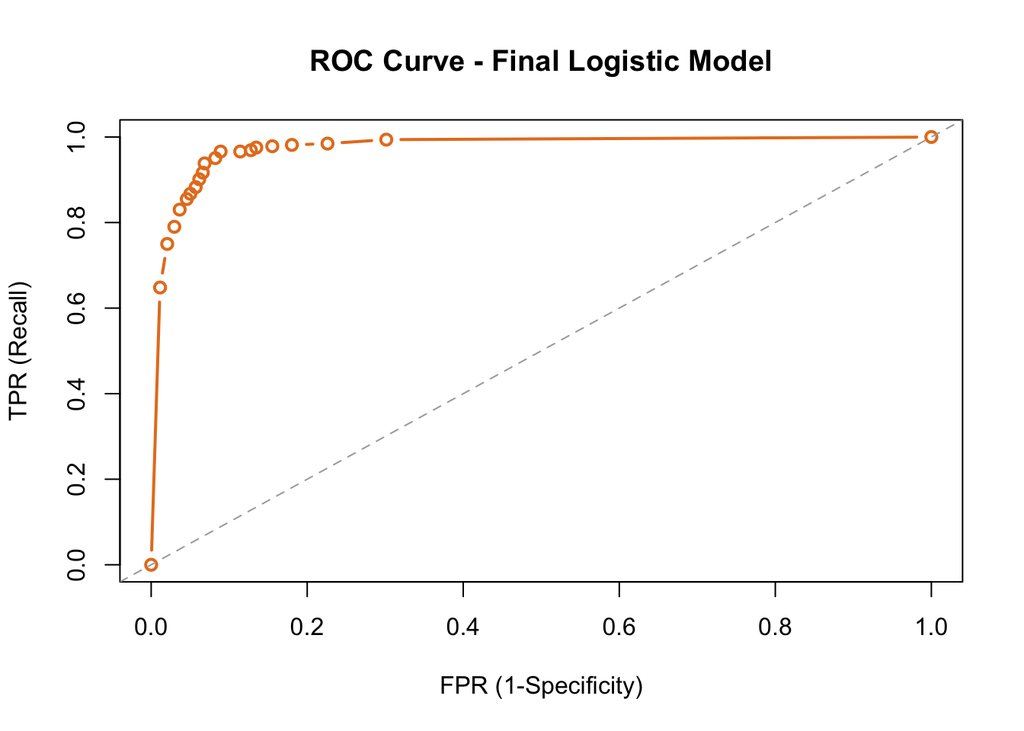

```r
roc_custom <- function(vera, prob, soglie = seq(0, 1, by = 0.05)) {
  res <- t(sapply(soglie, function(s) {
    pred <- ifelse(prob >= s, 1, 0)
    tpr <- sum(vera == 1 & pred == 1) / sum(vera == 1)
    fpr <- sum(vera == 0 & pred == 1) / sum(vera == 0)
    c(Soglia = s, TPR = tpr, FPR = fpr)
  }))

  plot(res[,3], res[,2], type = "b", col = "#e67e22", lwd = 2,
       main = "ROC Curve - Final Logistic Model", xlab = "FPR (1-Specificity)", ylab = "TPR (Recall)")
  abline(a = 0, b = 1, lty = 2, col = "darkgrey")
  return(as.data.frame(res))
}

tabella_soglie <- roc_custom(test_set$Class, prob_test)
```

# Conclusion

The Logistic Regression model is the best performer for this dataset. Its high Accuracy and F1-score indicate that the features provided (Area, Perimeter, etc.) have a clear probabilistic relationship with the rice variety, making this linear classifier highly effective for this specific task.